# Guida Polonia 2026 — ultima versione (28/06/2026)

# Guida Polonia 2026 — 4-11 agosto, 6 persone, da Varsavia alla Masuria a Danzica

> **✅ ULTIMA VERSIONE — aggiornata al 28 giugno 2026.** È il documento più recente e sostituisce ogni versione precedente dell’itinerario.

Una settimana lineare nel nord della Polonia, 7 notti: due a Varsavia, due sui laghi della Masuria, tre a Danzica. Voli diretti all’andata e al ritorno, van da 9 posti dal terzo giorno. Questa guida raccoglie tutto in un posto solo: programma ora per ora, dove mangiare, cosa vedere, regole della strada e checklist.

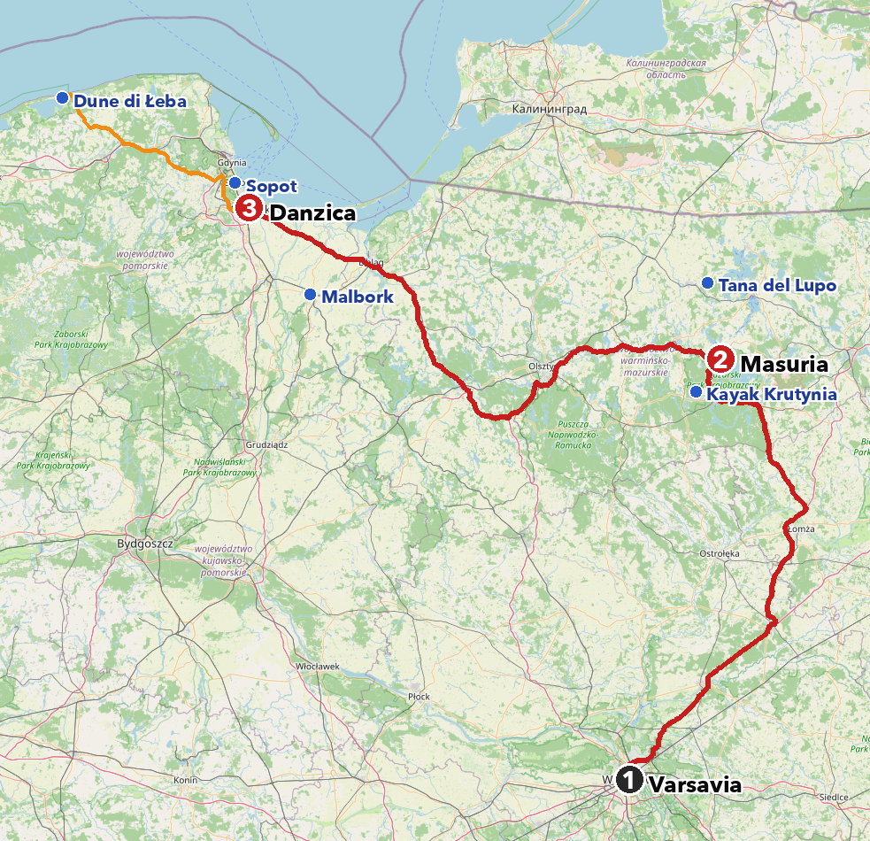

Mappa del percorso

## 1. Colpo d’occhio della settimana

| Giorno | Data | Base notte | Cosa si fa |
| --- | --- | --- | --- |
| **G1** | mar 4/08 | Varsavia (Hotel Verte) | Volo CTA→Modlin, transfer in centro (no van), Città Vecchia, cena di benvenuto |
| **G2** | mer 5/08 | Varsavia (Hotel Verte) | Zoo + villa Żabiński, bar mleczny, siesta, Łazienki o POLIN, cena |
| **G3** | gio 6/08 | Masuria (Robert’s Port) | Ritiro van in città, trasferimento ai laghi, cena pre-battello, crociera al tramonto |
| **G4** | ven 7/08 | Masuria (Robert’s Port) | 🔴 Giornata piena: kayak Krutynia + Tana del Lupo + cena memorabile |
| **G5** | sab 8/08 | Danzica (Hotel Sadova) | 🔴 Giornata piena: trasferimento + Castello di Malbork sulla strada |
| **G6** | dom 9/08 | Danzica (Hotel Sadova) | Dune di Łeba + foche al Sea Park, sera libera (opz. Galar al tramonto) |
| **G7** | lun 10/08 | Danzica (Hotel Sadova) | Danzica a fondo, galeone a Westerplatte, Sopot, cena di chiusura |
| **G8** | mar 11/08 | volo serale | Mattina libera a Danzica, riconsegna van, volo GDN→CTA |

## 2. Programma giorno per giorno

> Glossario rapido: *buffer* = margine di sicurezza che si lascia apposta perché tutto slitta; *slot* 🔒 = orario vincolato, va prenotato prima; *melex* = taxi elettrico aperto; *MOP* = autogrill polacco; *opłata serwisowa* = maggiorazione di servizio che alcuni ristoranti aggiungono in automatico al conto.

### G1 — martedì 4/08 · Arrivo a Modlin + prima sera a Varsavia

**Sveglia ~6:30** (per il volo delle 09:05). Niente van oggi: dall’aeroporto si va in centro coi mezzi, il van si prende il G3.

| Ora | Cosa | Dove | Note |
| --- | --- | --- | --- |
| 09:05 | ✈️ Volo diretto Ryanair FR5441 CTA→Modlin (WMI) | in volo | atterra 11:50, durata 2h45 |
| ~12:35 | 🚌/🚕 Modlin → centro Varsavia (no van) | Modlin → Stare Miasto | bus diretto FlixBus/Modlin Bus (~€8-11/pax) **oppure** 2 taxi (~180-220 zł in totale, più comodo per chi è stanco). No treno con cambi |
| ~15:00 | Check-in Hotel Verte, riposo | ul. Podwale 3/5 | reception 24h |
| ~15:45 | Passeggiata Città Vecchia (Piazza Mercato, Castello Reale esterni, barbacane, Sirenetta) | Stare Miasto | ritmo lento, gelato; pavé sconnesso → scarpe comode |
| ~17:45 | 🌇 Roof-garden della BUW (foto al tramonto) | ul. Dobra 56/66 (~1,3 km a piedi) | gratis, ascensori e rampe, aperto 8:00-20:00 |
| ~19:30 | 🥂 Cena di benvenuto — Restauracja Stolica | ul. Szeroki Dunaj 1/3 (~3 min a piedi) | anatra, żurek, pierogi, piano dal vivo |

**🔒 Da prenotare:** Stolica (+48 604 598 764), per 6 con qualche giorno di anticipo. Biglietti bus Modlin→Varsavia oppure 2 taxi. **☔ Se piove o si è stanchi dal volo:** salta il roof-garden, solo Città Vecchia sotto i portici + gelato al coperto. La cena resta (è al chiuso).

### G2 — mercoledì 5/08 · Varsavia a fondo (tutto coi mezzi)

**Sveglia ~7:30** (per essere allo Zoo all’apertura, evitare folla e caldo). Giornata stanziale, zero guida.

| Ora | Cosa | Dove | Note |
| --- | --- | --- | --- |
| ~8:30 | 🚊 Tram allo Zoo (no van) | centro → Praga | fermata “Ratuszowa-ZOO”; biglietto WTP zona 1 (20’ 3,40 zł / 75’ 4,40 zł) |
| **09:00** 🔒 | 🦁 Zoo di Varsavia + villa Żabiński (Giusti tra le Nazioni) | ul. Ratuszowa 1/3 | apre 9:00, ultimo ingresso 17:00; 45 zł intero / 35 ridotto. Presto = meno folla e caldo |
| ~12:45 | 🥛 Pranzo bar mleczny (mensa popolare) | Lindleya 14 | pierogi e zuppe, ~15-16 € per 6, genuino ed economico |
| ~14:15 | 😴 Siesta in hotel | Verte | il caldo di metà pomeriggio = riposo, non visite |
| ~15:30 | Parco Łazienki (pavoni, palazzo sull’acqua) **oppure** Museo POLIN | Łazienki / Muranów | Łazienki parco gratis (palazzo 20 zł); POLIN 45/35 zł, audioguida inclusa, tutto al chiuso |
| ~19:30 | 🍽️ Cena — Gospoda Kwiaty Polskie | ul. Wąski Dunaj 4/6/8 (~4 min a piedi) | cucina casalinga (pierogi, golonka, bigos), prezzi onesti |

**🔒 Da prenotare:** Gospoda Kwiaty Polskie (+48 22 887 65 20). Zoo: biglietto online consigliato ma non obbligatorio. **☔ Se piove:** lo Zoo si fa anche con pioggia leggera (molti padiglioni al coperto); con temporale forte anticipa POLIN (tutto al chiuso) al mattino. Se piove forte, POLIN al posto di Łazienki.

### G3 — giovedì 6/08 · Ritiro van + Masuria + battello al tramonto

**Sveglia ~7:30** (colazione, poi ritiro del van in città; partenza per la Masuria ~9:30).

> **Ritiro van oggi:** si ritira a Varsavia città, non a Modlin. Uffici: Sixt — Hotel InterContinental, ul. Emilii Plater 49, oppure Europcar — Hotel Sobieski. ⚠️ Disponibilità del 9 posti per le date 6→11/8 (alta stagione) e ritiro in città da confermare prenotando. Il van si rende a Danzica (GDN) il G8: noleggio di 5 giorni.

| Ora | Cosa | Dove | Note |
| --- | --- | --- | --- |
| ~8:30 | 🚕 Trasferimento all’ufficio noleggio | centro → Śródmieście | taxi/Bolt ~2,5 km, 2 vetture con 6 valigie |
| **~8:45** 🔒 | 🚐 Ritiro van 9 posti | ufficio noleggio | controllo mezzo, foto, confermare Euro 6, caricare i bagagli (45-60 min) |
| ~9:30 | 🚐 Varsavia → Mikołajki | S8 → S61 (Via Baltica) | 245 km, ~3h37, 0 pedaggi; cambio-guida a metà |
| ~11:15 | 🛑 Sosta-benessere | MOP zona Ostrów Maz./Łomża | 15-20 min, bagno e caffè |
| ~13:30 | Check-in Hotel Robert’s Port | Stare Sady (~4 km dal centro) | resort sul lago, parcheggio van di superficie |
| ~14:15 | 🏊 Relax al resort (piscina, jacuzzi, spiaggia) | Robert’s Port | la giornata-respiro, incluso |
| ~16:45 | 🍽️ Cena PRE-battello — Nóż w Wodzie | ul. Kajki 62/64, promenade | cena anticipata (vedi nota sotto): pesce di lago, selvaggina |
| **~18:35** 🔒 | Presentarsi al pontile (20-30’ prima) | pontile Mikołajki centro | — |
| **19:00-21:00** 🔒 | ⛵ Crociera al tramonto (Żegluga Mazurska) su Śniardwy | lago | 2h, 65/55 zł; tramonto ~20:45 visibile dal lago; chiedere ridotti pensionati (qui valgono) |

**🔒 Da prenotare:** van città (Sixt/Europcar); battello Żegluga Mazurska; Nóż w Wodzie per le ~16:45 (+48 609 073 434). **🧩 Perché si cena prima del battello:** il battello finisce alle 21:00 ma il giovedì Nóż w Wodzie chiude alle 20:00. Quindi al G3 si cena anticipata (16:45-18:00) prima di imbarcarsi, e la cena memorabile masuriana (Spiżarnia, aperta fino alle 22:00) si sposta al G4, la sera libera. **☔ Se c’è vento forte:** il battello salta per sicurezza → la cena resta comunque (già fatta), si recupera la spa del resort o la promenade.

### G4 — venerdì 7/08 · 🔴 Giornata piena · Kayak + Tana del Lupo + cena memorabile

**Sveglia ~7:00** (per far stare tutto in giornata).

> ⚠️ Giornata piena (~9h): ~150 km di guida frammentata + ~6h di attività. Valvola già impostata: Święta Lipka si salta di default, si fa solo se kayak e Tana del Lupo filano lisci.

| Ora | Cosa | Dove | Note |
| --- | --- | --- | --- |
| ~8:00 | 🚐 Resort → Krutyń (base kayak) | Mikołajki → Krutyń | ~30 km, operatore Sakowscy |
| **~8:45** 🔒 | 🛶 Spływ kajakowy Krutynia (Krutyń → Rosocha, 6 km) | fiume Krutynia | 2-3h in acqua, fiume facile, niente rapide; ~60 zł/pax. Ci si bagna: gli zii valutino |
| ~12:00 | Cambio e pranzo | Krutyń / Mikołajki | ~75 min, non comprimere |
| ~14:30 | 🐺 Wilczy Szaniec / Tana del Lupo (bunker QG di Hitler nel bosco) | Gierłoż | aperto 8:00-20:00; ~30 zł intero / ~25 ridotto + parcheggio ~15-20 zł; ~2h, bosco piano |
| ~16:30 | ⛪ Święta Lipka (basilica barocca, organo) — **OPZIONALE** | ~15 km da Gierłoż | da saltare di default; basilica gratis, organo a offerta libera; solo se c’è energia |
| ~19:30 | 🥂 Cena memorabile — Spiżarnia Mazury | Plac Handlowy 14, Mikołajki | ~10 min in van dal resort; pesce di lago, selvaggina, aperta fino alle 22:00 |

**🔒 Da prenotare:** kayak Sakowscy (+48 600 029 035, la sera prima); Spiżarnia (+48 87 421 52 18). **🔧 Se il gruppo è cotto:** salta Święta Lipka (già di default) → la giornata scende a ~7h. Se anche il kayak stanca, la Tana del Lupo da sola regge la giornata. **☔ Se piove:** il kayak si fa anche con pioggia leggera, salta col temporale → in alternativa Tana del Lupo al mattino (il bosco ripara) + Święta Lipka al coperto. Se piove tutto il giorno: spa al resort + Tana del Lupo nel pomeriggio.

### G5 — sabato 8/08 · 🔴 Giornata piena · Masuria → Malbork → Danzica

**Sveglia ~6:15** (partenza ~7:15 per arrivare a Malbork sullo slot delle ~11:00 con margine).

> ⚠️ Giornata piena (~10h porta-a-porta): Malbork non è una gita A/R, è una sosta-visita sulla strada dai laghi alla costa. ~4h37 di guida totale + 3,5h di castello. Dopo, il G6 parte lento.

| Ora | Cosa | Dove | Note |
| --- | --- | --- | --- |
| ~7:15 | 🚐 Mikołajki → Malbork | S7 | 236 km, ~3h25, 0 pedaggi; caricare il van la sera prima |
| ~9:00 | 🛑 Sosta-benessere | MOP zona Nidzica/Olsztynek | 15-20 min |
| **~11:00** 🔒 | 🏰 Castello di Malbork (Trasa Historyczna, audioguida IT inclusa) | Malbork | interni 9-19, ultimo ingresso 16:30; **slot online obbligatorio** (limite 500/h, sabato il più affollato); 80 zł intero / 60 ridotto; ~3,5h |
| ~14:30 | 🥪 Pranzo (zona castello) | Malbork | facciata da fotografare dall’altra sponda del Nogat |
| ~15:45 | 🚐 Malbork → Danzica | DK55 → S7 | 62 km, ~1h12, 0 pedaggi |
| ~17:00 | Check-in Hotel Sadova (3 notti), riposo | ul. Łąkowa 60 | parcheggio di superficie sul posto, piscina/spa |
| ~18:30 | Passeggiata serale lungo la Motława (Długi Targ, il Żuraw) | centro Danzica | ⚠️ Fiera San Domenico in corso (folla) |
| ~19:45 | 🍽️ Cena — Restauracja Kubicki | ul. Wartka 5 (~13 min a piedi) | il più antico di Danzica (1918); golonka, anatra, piano-singer |

**🔒 Da prenotare (critico):** Malbork slot online (bilety.zamek.malbork.pl) + audioguida IT — il vincolo più rigido della settimana. Cena Kubicki (+48 58 301 00 50, San Domenico riempie tutto). **🔧 Se in ritardo:** ultimo ingresso a Malbork è 16:30, quindi anche con 1h di ritardo si entra; se il gruppo è stanco c’è il percorso “corto” del castello (~2h invece di 3,5h). **☔ Se piove:** Malbork è in gran parte al chiuso, la pioggia non lo ferma. La passeggiata serale si accorcia, la cena è al coperto comunque.

### G6 — domenica 9/08 · Dune di Łeba + foche al Sea Park

**Sveglia ~8:00 (giornata lenta al risveglio)** — colazione comoda, partenza dopo. È la mossa che rompe le 3 mattine presto di fila. Le dune non hanno orario stretto, si parte con calma.

| Ora | Cosa | Dove | Note |
| --- | --- | --- | --- |
| ~9:00 | 🚐 Danzica → Łeba/Rąbka (ingresso dune) | S6 → DW214 | 111 km, ~2h, 0 pedaggi; cambio-guida |
| ~11:15 | Arrivo Rąbka, scelta mezzo per le dune | Rąbka | ingresso parco 10 zł intero / 5 ridotto; melex in agosto fa code → mettere in conto ~1,8 km a piedi (sterrato piano) o bici |
| ~11:45 | 🏜️ Dune mobili (Wydma Łącka), salita e panorama | Parco Słowiński | ~2h30; più facile dopo la pioggia; col sole secco si affonda → cappello + acqua. ⚠️ Salita non banale per gli over-50: possono fermarsi al panorama basso |
| ~14:15 | 🥪 Pranzo | Łeba/Sarbsk | ~75 min |
| ~15:45 | 🦭 Sea Park Sarbsk (foche) — attrazione seduta, ok zii | ul. Foki 1, Sarbsk (~10 km da Łeba) | aperto 9:00-17:00; spettacoli foche 10:00 e 16:00 → puntare a quello delle 16:00; 119 zł intero / 99 ridotto + parcheggio 20 zł |
| ~17:30 | 🚐 Rientro a Danzica | S6 | 111 km, ~2h; cambio-guida |
| ~19:45 | 🏊 Relax piscina/spa + cena libera (Papierówka in hotel) | Sadova | sera scarica dopo la lunga guida |

**🆕 Opzione serale facoltativa — Galar al tramonto sul Motława** (solo se il gruppo regge): replica di galar fluviale del ’700, 12 posti, imbarco ul. Dokowa 1 (Dok Cesarski). Crociera 90-100 min al tramonto, 95 zł adulti / 60 zł (10-16 anni); coperte fornite, narrazione PL/ENG. ⚠️ Orario serale esatto per il 9/8 **da confermare su galar.org** (varia col tramonto, ~20:30-20:45); barca aperta, sera fresca sull’acqua. Dal Sadova: treno SKM una fermata o Bolt (~10 min).

**🔒 Da prenotare:** Sea Park = biglietto in cassa. Galar (se scelto) su galar.org, cancellazione gratis fino a 24h prima. **🔧 Se la giornata è troppo lunga:** saltare il Sea Park (le foche sono l’elemento sacrificabile) e rientrare prima dalle dune; e/o saltare il Galar (è già opzionale). **☔ Se piove forte:** giornata quasi tutta all’aperto. Le dune con pioggia leggera sono più facili; con temporale → solo Sea Park (al coperto) + spa. Il Galar (barca aperta) salta con pioggia/vento serale.

### G7 — lunedì 10/08 · Danzica, galeone, Sopot, cena di chiusura

**Sveglia ~8:30 (lenta)** — penultimo giorno, ritmo rilassato, niente guida lunga.

| Ora | Cosa | Dove | Note |
| --- | --- | --- | --- |
| ~9:45 | Danzica a fondo: Basilica di Santa Maria, via reale, ambra al Jarmark | centro storico | torre S. Maria = 408 gradini, no ascensore → over-50 meglio la Torre del Municipio. Ambra: solo artigiani con certificato |
| **12:00** 🔒 | ⚓ Galeone “Lew” → Westerplatte (dove iniziò la 2ª GM) | imbarco Motława (ul. Wartka) | partenze ogni ora 10:00-19:00; **A/R 100/75 zł**, sola andata 75/60 zł; ~2h30 A/R, tutto seduti |
| ~14:30 | 🥪 Pranzo leggero | lungofiume Danzica | — |
| ~15:45 | 🚆 Treno SKM → Sopot (no van) | Danzica → Sopot | ~25 min, ~6,50 zł, ogni 10-15’ |
| ~16:15 | Sopot: molo di legno (~511 m), spiaggia, via Monte Cassino, bagno nel Baltico | Sopot | ⚠️ il molo è **a pagamento in estate: 10 zł intero / 5 ridotto**; spiaggia e via Monte Cassino gratis |
| ~18:15 | 🌅 (opzionale) Orłowo al tramonto, treno SKM da Sopot | Orłowo | +1-1,5h: solo se c’è energia; non sostituisce Sopot né la cena |
| ~20:00 | 🥂 Cena di chiusura — Zafishowani | ul. Tokarska 6 (~15 min a piedi) | pesce/frutti di mare fine-dining accanto al Żuraw. ⚠️ **+12,5% di opłata serwisowa automatica** sul conto |

**🔒 Da prenotare:** Zafishowani (+48 661 511 811 — San Domenico riempie tutto; ricordare il +12,5% serwis). Galeone Lew = biglietto in cassa/online, puntare alle 12:00. **🔧 Valvola:** Orłowo è coda facoltativa, si taglia per primo. Se anche Sopot stanca, si rientra prima. **☔ Se piove:** il galeone va comunque (coperto sotto coperta), Sopot si accorcia; alternativa al chiuso: Museo Marittimo Nazionale o ECS.

### G8 — martedì 11/08 · Ultima mattina a Danzica → volo serale

**Sveglia ~8:30 (lenta)** — il volo è di sera, mattina libera senza fretta.

> 🎉 Il rientro è la parte facile: solo 16 km / 33’ dall’hotel all’aeroporto. Tutta la mattina e il primo pomeriggio liberi.

| Ora | Cosa | Dove | Note |
| --- | --- | --- | --- |
| ~9:45 | Passeggiata d’addio Motława + Długi Targ, ambra al Jarmark, eventuale Torre del Municipio | centro storico | ⚠️ è martedì: ECS chiuso, Museo Ambra in ristrutturazione → niente museo grosso, solo passeggiata leggera |
|  | **Alternativa relax:** mattinata spa al Sadova (piscina + sauna) | Sadova | la scelta più riposante |
| ~12:15 | Pranzo leggero | centro Danzica | non appesantirsi prima del volo |
| ~13:30 | Rientro hotel, check-out, caricare bagagli | Sadova | controllare di non lasciare nulla |
| ~16:00 | 🚐 Danzica → aeroporto GDN + riconsegna van | al. Armii Krajowej | 16 km, ~33 min |
| ~17:00 | Riconsegna van, check-in Wizz, controlli | GDN | Wizz chiude i banchi ~2h prima → essere qui alle ~17:00; ⚠️ regole bagaglio Wizz ≠ Ryanair |
| **19:15** 🔒 | ✈️ Volo diretto Wizz W6 1685 GDN→Catania | in volo | atterra 22:20, durata 3h05 |

**🔒 Da confermare:** van one-way Varsavia città → GDN (maggiorazione interregionale), riconsegna a GDN. **🔧 Valvola:** se bagagli o traffico preoccupano, anticipare la riconsegna van alle ~15:30.

## 3. Dove mangiare

> Costo medio a persona = una portata principale + bevanda (per le cene memorabili: antipasto/zuppa + principale + bevanda). Cambio indicativo 1 € ≈ 4,30 zł.

### Varsavia (base: Hotel Verte, Città Vecchia)

| Locale | Pasto / giorno | €/pax | Distanza dal Verte | Telefono |
| --- | --- | --- | --- | --- |
| **Restauracja Stolica** (Szeroki Dunaj 1/3) | 🥂 Cena benvenuto · G1 | ~€26-34 (+10% serwis incluso) | ~250 m, ~3 min a piedi | +48 604 598 764 |
| **Gospoda Kwiaty Polskie** (Wąski Dunaj 4/6/8) | Cena · G2 | ~€18-24 (+10% serwis incluso) | ~300 m, ~4 min a piedi | +48 22 887 65 20 |

### Masuria (base: Hotel Robert’s Port, Stare Sady)

| Locale | Pasto / giorno | €/pax | Distanza dal resort | Telefono |
| --- | --- | --- | --- | --- |
| **Nóż w Wodzie** (ul. Kajki 62/64, promenade) | Cena pre-battello · G3 | ~€14-20 | ~4-5 km, ~10 min in van | +48 609 073 434 |
| **Spiżarnia Mazury** (Plac Handlowy 14) | 🥂 Cena memorabile · G4 | ~€24-32 | ~4-5 km, ~10 min in van | +48 87 421 52 18 |

⚠️ Nóż w Wodzie il giovedì chiude alle 20:00: la cena va fatta prima del battello (vedi G3). Spiżarnia è aperta lug-ago tutti i giorni 12:00-22:00.

### Danzica (base: Hotel Sadova, ul. Łąkowa 60)

| Locale | Pasto / giorno | €/pax | Distanza dal Sadova | Telefono |
| --- | --- | --- | --- | --- |
| **Restauracja Kubicki** (ul. Wartka 5, sul Motława) | Cena · G5 | ~€20-28 | ~1,1 km, ~13 min a piedi | +48 58 301 00 50 |
| **Papierówka Cider Garden** (dentro l’Hotel Sadova) | Cena libera · G6 | ~€18-28 (⚠️ listino da confermare in reception) | 0 min, è in hotel | via reception Hotel Sadova |
| **Zafishowani** (ul. Tokarska 6, sul Motława) | 🥂 Cena chiusura · G7 | ~€26-36 (⚠️ +12,5% serwis) | ~1,2 km, ~15 min a piedi | +48 661 511 811 |

⚠️ Fiera di San Domenico (25/7-16/8): prenotare TUTTE le cene di Danzica con anticipo, la città è piena su tutti e 3 i giorni.

**In una settimana le cene fuori pesano circa €146-202 a persona**, di cui ~€76-102 nelle 3 cene memorabili. Per i pranzi economici, puntare sui *bar mleczny* (mense popolari) ed evitare i ristoranti-trappola della Piazza del Mercato a Varsavia e di via Długa a Danzica.

## 4. Cosa vedere

> Cambio indicativo 1 € ≈ 4,30 zł. ⚠️ Ridotti: i due over-50 (Carlo, Giovanna) e gli zii NON hanno diritto al ridotto nei musei polacchi (è per studenti ≤26 e pensionati con tessera). Pagano l’intero quasi ovunque. Eccezione: al battello di Mikołajki i ridotti pensionati valgono.

[output not shown]

## 5. Regole della Polonia

### ⭐ Top 5 da ricordare

1. **Alcol alla guida = praticamente ZERO.** Limite legale 0,2 g/l (un quinto di quello italiano). Chi guida — Carlo e lo zio — non beve NULLA, neanche una birra a pranzo. Attenzione anche alla mattina dopo una serata pesante.
2. **Fari accesi sempre**, anche di giorno e d’estate. Quasi tutti i van recenti lo fanno da soli all’accensione; controllate.
3. **Il van Euro 6 entra a Varsavia senza problemi** (la zona ambientale SCT blocca solo i veicoli vecchi). Verificate la classe Euro sul libretto/contratto.
4. **Borseggi nella folla, non rapine.** La Polonia è sicura; il rischio vero è il borseggio in tram, stazioni e nelle grandi folle — e a Danzica c’è la mega-folla della Fiera di San Domenico. Marsupio davanti, niente portafogli in tasca posteriore.
5. **Soldi e taxi: solo i canali giusti.** Cambiate nei *kantor* in centro città, MAI in aeroporto; al bancomat scegliete sempre “in złoty (PLN)”, mai “in euro”; per i taxi usate Bolt o FreeNow, mai chi vi avvicina in strada.

### Guida

- **Limiti:** 50 km/h in città, 90 extraurbana, 100 a doppia carreggiata, 120 strada espressa “S”, 140 autostrada “A”. Il van da 9 posti sotto 3,5 t è trattato come un’auto.
- **Telefono:** vietato in mano, solo vivavoce/supporto.
- **Cinture per tutti** (davanti e dietro); seggiolino/rialzo per chi è sotto 150 cm.
- **Pedaggi:** in Polonia non esiste la vignetta per auto/van e il van sotto 3,5 t non deve registrarsi a e-TOLL. Sul vostro itinerario i pedaggi sono **0** (il percorso non tocca l’A1 a pagamento). Tenete comunque contanti in złoty e una carta per ogni evenienza.
- **Dotazioni obbligatorie nel van:** triangolo + estintore. Su un van a noleggio di solito ci sono già: controllate alla consegna.
- **Controllo di polizia:** accostare, spegnere il motore, mani in vista, restare cortesi. Patente italiana valida. Multe pagabili sul posto (tenere contanti in złoty). Mai denaro “informale”.
- **Pedoni:** dovete dare la precedenza anche a chi si sta avvicinando alle strisce. Multe salatissime.
- **Parcheggi:** per il van conviene un parcheggio di superficie/custodito appena fuori dal centro, poi a piedi o tram. App utili: moBiLET, SkyCash.

### Mance

- Ristorante ~10% (15% se servizio molto buono); bar arrotondamento; taxi si arrotonda; facchino 5-10 zł a valigia.
- Si lascia **quasi sempre in contanti**, anche pagando il conto con carta.
- ⚠️ Trappola: se pagate in contanti e dite **“dziękuję” (grazie)** mentre porgete i soldi, il cameriere capisce “tenga il resto”. Se volete il resto, NON dite grazie in quel momento: dite la cifra totale (es. *“40, proszę”*) e ringraziate dopo aver ricevuto il resto.
- Controllate se il conto ha già *opłata serwisowa* / *serwis wliczony* (servizio incluso): in quel caso non aggiungete altro.

### Usanze

- **Saluti:** stretta di mano ferma guardando negli occhi. Le tre parole magiche: *proszę* (per favore), *dziękuję* (grazie), *przepraszam* (mi scusi).
- **Brindisi:** “Na zdrowie!” guardando negli occhi (non il bicchiere). Chi guida brinda con acqua/analcolico.
- **In chiesa** (Malbork, Santa Maria, Święta Lipka): spalle e ginocchia coperte, voce bassa, foto senza flash; se c’è messa, non girate a fotografare.
- **Puntualità** apprezzata (tour, ristoranti, check-in).

### Sicurezza

- **Numeri di emergenza:** 112 (unico europeo), 997 polizia, 998 vigili del fuoco, 999 ambulanza.
- **Cambio valuta:** *kantor* in città, mai in aeroporto; chiedete sempre quanti złoty ricevete in totale PRIMA di consegnare i soldi.
- **Bancomat:** scegliete sempre “in złoty”, usate ATM dentro le banche, diffidate degli sportelli gialli/blu in strada (es. Euronet).
- **Acqua del rubinetto:** potabile e sicura nelle città.
- **Farmacie:** insegna *apteka* (croce verde); 24h = *apteka całodobowa*. Portate la Tessera Sanitaria europea.

## 6. Checklist prenotazioni

> In ordine di urgenza. La esegue Raffaele. Importi = stime da riconfermare.

### 🔴 Urgenza 1 — subito (prezzi e posti si esauriscono)

- **Voli (entrambi diretti):** Andata Ryanair FR5441 CTA→Modlin, 4/08 09:05→11:50, su ryanair.com (6 pax + stiva). Ritorno Wizz W6 1685 GDN→CTA, 11/08 19:15→22:20, su wizzair.com. ⚠️ Due prenotazioni separate, regole bagaglio diverse. Voce più volatile: prenotare presto.
- **Van 9 posti:** preventivo Sixt (ul. Emilii Plater 49) o Europcar (Hotel Sobieski), ritiro Varsavia città 6/8 → riconsegna GDN 11/8, 5 giorni. Aggiungere 2° guidatore + assicurazione kasko/SCDW + km illimitati. ⚠️ Confermare disponibilità del 9 posti in città + maggiorazione one-way. Verificare altezza/lunghezza e classe Euro 6.
- **Transfer Modlin→Varsavia (4/8):** bus diretto FlixBus/Modlin Bus oppure 2 taxi.
- **3 alloggi:** Hotel Verte 5★ Varsavia 2N (4-6/8) · Hotel Robert’s Port Masuria 2N (6-8/8) · Hotel Sadova 4★ Danzica 3N (8-11/8). Riconfermare prezzi per 6 ospiti / 3 camere.
  - Verte: [booking.com](https://www.booking.com/hotel/pl/verte-warsaw-autograph-collection.html)
  - Robert’s Port: [booking.com](https://www.booking.com/hotel/pl/roberts-port.html)
  - Sadova: [booking.com](https://www.booking.com/hotel/pl/sadova.html)

### 🟠 Urgenza 2 — appena prenotabile (posti a numero chiuso)

- **Malbork:** slot online obbligatorio per sabato 8/8 ~11:00 su bilety.zamek.malbork.pl + audioguida italiano. ⚠️ Sabato si esaurisce.
- **Battello al tramonto Mikołajki** (gio 6/8, 19:00): bilety.zeglugamazurska.com.pl; chiedere ridotti pensionati.
- **Kayak Krutynia** (ven 7/8): Sakowscy +48 600 029 035, prenotare la sera del G3.
- **Galeone Westerplatte** (lun 10/8, ~12:00): cassa/online, presentarsi 20-30’ prima.
- **Sea Park / foche** (dom 9/8): biglietto in cassa.
- **Galar al tramonto** (opzionale, dom 9/8): galar.org, ⚠️ validare prima l’orario tramonto del 9/8 e il meteo.

### 🟡 Urgenza 3 — pochi giorni prima / la sera prima

- **Cene memorabili (presto):** Stolica +48 604 598 764 (G1) · Spiżarnia +48 87 421 52 18 (G4) · Zafishowani +48 661 511 811 (G7).
- **Altre cene (qualche giorno/sera prima):** Gospoda +48 22 887 65 20 (G2) · Nóż w Wodzie +48 609 073 434 (G3, cena pre-battello ~16:45) · Kubicki +48 58 301 00 50 (G5).
- **Spostamenti locali:** tram WTP per lo Zoo (G2) e treno SKM per Sopot (G7) — niente prenotazione, biglietto in loco.

### 💳 Promemoria pagamenti

- **Contanti in złoty** per: parcheggi di superficie, battello, foche, tram Zoo, molo Sopot (10 zł/pax), tassa di soggiorno Danzica (~3,46 zł/pax/giorno, al check-out del Sadova), mance, chioschi.
- **Carta di Carlo** per le cauzioni (van + eventuale alloggio): bloccate, tornano indietro.
- **App utili:** Bolt/Uber (taxi), biglietti SKM/WTP.

## 7. Budget (appendice)

> Gruppo di 6 persone, voci di gruppo divise per 6. Cambio 1 € ≈ 4,30 zł. Tetto: €2.000/pax tutto incluso.

**Totale per persona: ~€1.791 centrale · ~€2.061 pessimistico.** Il centrale è dentro il tetto con ~€209 di margine; il pessimistico lo supera di ~€61 solo nel caso peggiore (tutte le voci volatili ai massimi insieme), ed è coperto dal cuscinetto contingenze. Come rete di sicurezza ulteriore resta la “leva Cosy Flat” (appartamento al posto del Verte a Varsavia: −€276/pax).

| Voce | €/pax centrale | €/pax pessimistico |
| --- | --- | --- |
| Volo a/r diretto (con stiva) | €210 | €250 |
| Van 9 posti (5 gg, ~950 km, 0 pedaggi) ÷6 | €182 | €243 |
| Transfer Modlin→Varsavia + tram Zoo | €9 | €14 |
| Alloggi (3 basi, 7 notti) ÷6 | €965 | €965 |
| Esperienze (kayak, battello, Malbork, dune, Tana del Lupo, galeone, foche…) | €109 | €130 |
| Cibo (8 pasti fuori + 3 cene memorabili + spesa) | €112 | €190 |
| Costi vivi in loco (parcheggi, tassa soggiorno, mance, acqua/gelati) | €87 | €123 |
| Cuscinetto contingenze (~7-8%) | €117 | €146 |
| **Totale /pax** | **~€1.791** | **~€2.061** |

La voce più pesante sono gli alloggi (€965/pax); la più volatile è il volo (prenotare presto può far scendere di €30-50/pax). I pedaggi sono azzerati perché il percorso non tocca l’A1 a pagamento.

## 8. Riepilogo spostamenti

> Tutte le tratte del viaggio con km, tempo (buffer incluso) e pedaggi. Il van entra in scena dal G3 (ritiro a Varsavia città): i primi 2 giorni sono coi mezzi.

| G | Tratta | Mezzo | km | Tempo | Pedaggi |
| --- | --- | --- | --- | --- | --- |
| 1 | Catania → Modlin | ✈️ aereo (Ryanair FR5441) | — | 2h45 | — |
| 1 | Modlin → centro Varsavia | 🚌 bus o 🚕 2 taxi | ~41 | ~1h-1h15 | — |
| 2 | Centro → Zoo e ritorno | 🚊 tram WTP | ~9 (A/R) | ~25-30 min/tratta | ~3,40-4,40 zł/corsa |
| 3 | Verte → ufficio noleggio | 🚕 taxi/Bolt | ~2,5 | ~15 min | — |
| 3 | Varsavia città → Mikołajki | 🚐 van | 245 | ~3h37 + sosta | 0 |
| 3 | Resort ⇄ centro Mikołajki | 🚐 van | ~9-10 (A/R) | ~10 min/tratta | 0 |
| 4 | Resort → Krutyń (kayak) | 🚐 van | ~30 | ~40 min | 0 |
| 4 | Krutyń → Tana del Lupo | 🚐 van | ~55 | ~1h | 0 |
| 4 | Tana del Lupo → resort (+ opz. Święta Lipka) | 🚐 van | ~50-65 | ~1h-1h15 | 0 |
| 5 | Mikołajki → Malbork | 🚐 van | 236 | ~3h25 + sosta | 0 |
| 5 | Malbork → Danzica | 🚐 van | 62 | ~1h12 | 0 |
| 6 | Danzica → Łeba/Rąbka | 🚐 van | 111 | ~2h + sosta | 0 |
| 6 | Łeba → Sea Park Sarbsk | 🚐 van | ~10 | ~15 min | 0 |
| 6 | Łeba/Rąbka → Danzica | 🚐 van | 111 | ~2h + sosta | 0 |
| 6 | (opz.) Sadova ⇄ Galar | 🚆 SKM o Bolt | ~2,3 | ~10 min | ~6,50 zł SKM |
| 7 | Danzica → Sopot e ritorno | 🚆 treno SKM | ~26 (A/R) | ~25 min/tratta | ~6,50 zł/corsa |
| 7 | (opz.) Sopot → Orłowo e ritorno | 🚆 treno SKM | ~10 (A/R) | pochi min | tariffa SKM |
| 8 | Danzica → aeroporto GDN | 🚐 van | 16 | ~33 min | 0 |
| 8 | Danzica (GDN) → Catania | ✈️ aereo (Wizz W6 1685) | — | 3h05 | — |